# Untitled

Dennis Tseng

2021/3/11

## 前言

這學期在新聞所修了聯合報系主管開設的〈新聞編輯與資訊設計〉，課堂上老師請大家以聯合報為例，思考報紙的未來。

報紙離年輕人實在很遠，除非家裡有訂報紙，網路原生世代從小就浸淫於網路媒體與科技平台。對媒體業有興趣的朋友們，平常也很少討論這個題目，大家的目光更多放在如何經營網路媒體，像是科技平台與媒體的傾軋，以及收益漸減後怎麼替媒體網站找出路，例如付費牆的諸多實驗等。

[output not shown]

自己最感興趣的資料新聞，因為仰賴媒介的豐富度，很大程度的排除了印刷。並不是說報紙上就沒有資訊圖表、就沒有好的資訊視覺化，只是因為想帶給讀者更好的閱讀體驗，需要利用更能夠適應讀者閱讀裝置的、具有動態效果的、呈現手法豐富的媒介。對敘事的可能性有所追求，所以選擇數位呈現。

將主題再拉回報紙，知道報紙讀者日益減少，報業經營越發困難，但少到什麼地步、又有哪些面向困難？這些問題都需要從資料和研究中找答案。我會從報業面臨的現況開始，爬梳報業的收入組成與支出流程，並逐項探討可能的改善方向；最後則往上一層，嘗試勾勒大眾報紙可能的新受眾與新定位，並回答老師的問題：「報紙的未來在哪里？」

## 核心問題：大眾媒體的衰落

有很多專書與文章討論網路崛起對印刷媒體的打擊，不只是新聞作為資訊商品的價格改變，也不只是印刷品與網路的媒介特性差異，周欽華在[〈 媒體即服務（Media as a service）〉](https://daodu.tech/07-28-2016-%E5%AA%92%E9%AB%94%E5%8D%B3%E6%9C%8D%E5%8B%99%EF%BC%88media-as-a-service%EF%BC%89)文中指出，「報紙不再壟斷資訊」才是關鍵。

媒介經濟學學者利用雙元商品市場(dual product markets) 描述媒體產業。以報紙為例，第一種市場是媒介產品市場，一般消費者利用金錢與時間向媒體經營者購買新聞資訊，第二種市場則是注意力市場，廣告主利用金錢向媒體經營者購買消費者的注意力。從前，報紙能夠壟斷資訊，消費者若不讀報紙，則不能了解國家大事，所以消費者必須購買報紙；廣告主想接觸大量受眾，也沒有其他可以選擇的替代廠商，只能在報紙上投放廣告。在這樣的情況下，報紙成為了大眾媒體，並擁有很好的銷量。

但在網路崛起後，媒介產品市場中湧入更多玩家，無論報紙的價格壓得多低，報紙的張數有多少，網路上總能找到更便宜、更接近免費的資訊商品，報社不僅失去從前壟斷地位，有不少玩家直接被踢出市場；注意力市場也不遑多讓，社群平台收割了更多注意力，不只提供了新的「大眾」，更能夠利用數據為注意力商品加值。

從最佳資訊獲取來源的地位跌下神壇，報紙市場整體的發行量穩定下滑，如此一來，報紙是不是非得拋棄大眾化的經營方式？利基市場會是報業的新容身之處嗎？

## 報紙的收支結構

報業的收支可以依照業務範圍，分成報紙作為主業與其他副業。主業與副業不必然以收入規模區分，副業也可能扛起集團營收重責，因為核心關懷仍是報紙，在此視報紙的產製為主頁。

先看收入，將報紙主業的收入依照二元商品市場區分，分別是銷售商品的售報收入，以及銷售注意力的廣告收入。支出部分，則按照生產流程區分為產製、印刷、分發。

### 售報收入

計算售報收入的基本公式是**售價 x 銷售量**。報紙售價會因為通路與需求量略有不同，後續再談；銷售量是報業的重要指標，它不僅代表售報收入，也是對著廣告主釋放訊息的火力展示，與廣告版位價格有著緊密關係。

除了各家報紙的自我宣稱以外，並沒有中央集權的機構計算報紙發行量。發行量涉及商業操作相關的營業秘密，例如報社決定付出多少成本推廣報紙，且若經過統計後，發現報社宣稱的發行量是膨風而來，會影響賣廣告時的議價能力；再者，計算銷量本身也是開銷，除了曾風靡一時、現已收攤的免費報紙爽報以外，近十多年來，台灣報業僅有自由時報與蘋果日報，曾經公開委託[中華民國傳媒稽核認證會](https://www.abc.org.tw/)(The Audit Bureau of Certification，簡稱 ABC) 稽核付費報紙發行量[^1]。

因為沒有市場整體的發行量數據，我只能先利用 ABC 的公開資料，勾勒出自由時報 2007 年 ~ 2017 年的報紙發行量漲跌。值得慶幸的是，自由時報的閱讀率（受訪時七天內曾經閱讀過此報紙）在台灣所有報紙中排名最高（潤利艾克曼公司，2020）[^2]，老師也在課堂上指出，自由時報的發行量是四大報之首，因此自由時報的數據仍有一定代表性。

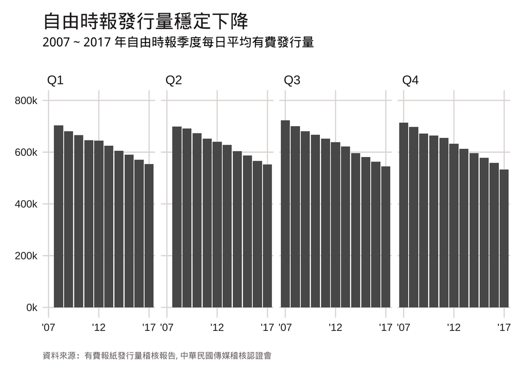

因為發行量受季節波動影響，我將資料依照季度拆分後再各自比較。從圖中可以發現，無論是一年中的哪個季度，自由時報的發行量都穩定下降。

然而，每年、每季度銷量的顆粒度太粗，只能知道發行量下跌，還是無法確定發行量下降的原因，是因為訂戶減少？還是因為零售銷量下降？先前也有新聞提到有些公部門陸續停訂報紙，也就是大宗銷售量下滑，會是這個原因嗎？所以，我先利用分銷通路(channel) 拆分自由時報的發行量。

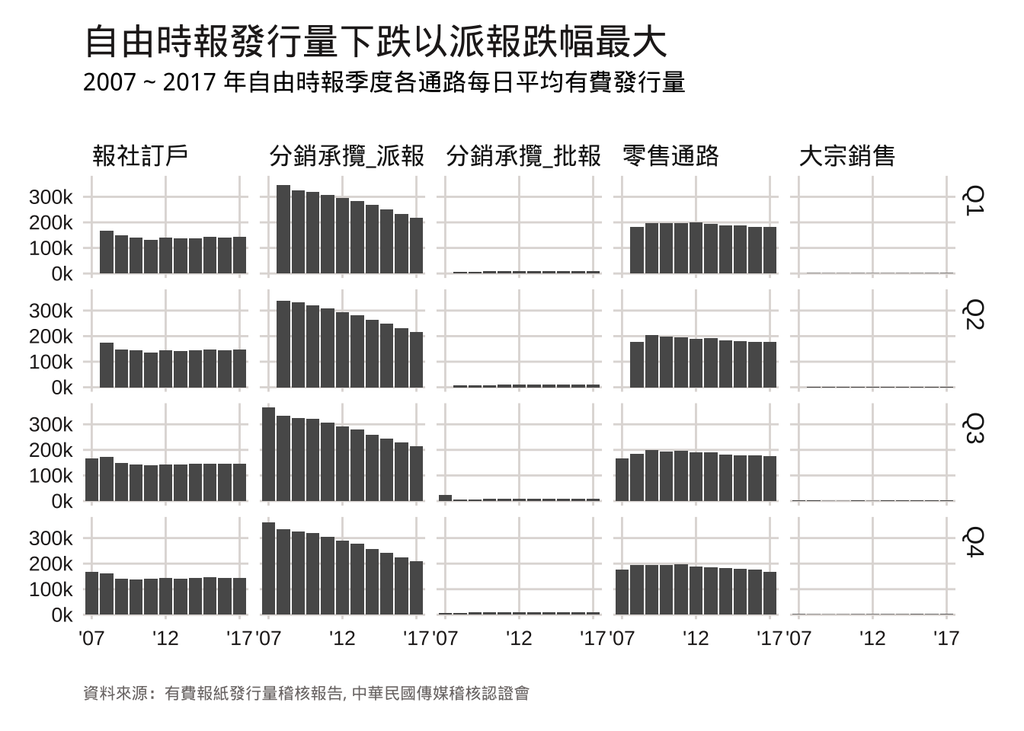

如圖所示，通路主要區分成報社訂戶、分銷承攬、零售通路、大宗銷售，其中報社訂戶指的是消費者直接向報社長期訂閱，分銷承攬可以細分為派報與批報，派報指經銷商向報社訂購後派發，批報指經銷商向報社買斷，零售通路則是報社和經銷商在零售通路例如便利商店所賣出的份數，大宗銷售則是機關團體訂購的份數。

無論是報社訂戶或者分銷承攬派報，都有下跌的情況，又以派報的數量下跌最多。而零售通路雖然曾經上漲，但後續又慢慢下跌，基本上持平。大宗銷售的絕對值非常小，對銷量的貢獻度不高。綜合不同通路的收入，報社來自訂戶與分銷承攬的固定收入減少，零售通路與大宗採購量也沒有增加。看起來，發行量下降是一件全面性的事情。

除了通路以外，我再從區域的角度切分銷量數字。想問的問題是，有沒有可能北部人逐漸不那麼愛看報紙了？

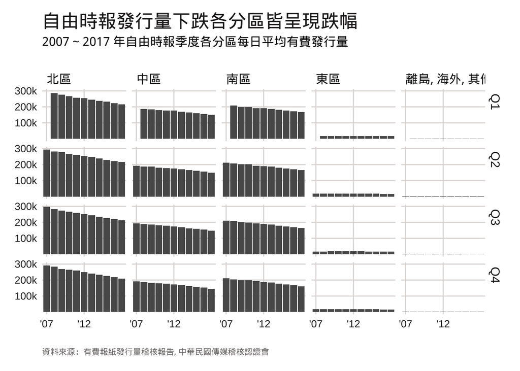

如圖所示，無論北、中、南、東、離島海外與其他，各區都呈現全面性的下降。看來售報收入下降已經勢不可擋，那麼，廣告收入又是如何？

### 廣告收入與受眾輪廓

在台北市媒體服務代理商協會每年出版的媒體白皮書中，都會整理台灣傳統媒體與數位媒體的廣告收入。傳統廣告資料來源是尼爾森(Nielsen)的廣告監播服務，數位廣告資料來源則是台灣數位媒體應用暨行銷協會(DMA)。

不用看圖也能猜想，報紙的廣告收入必然呈現下跌趨勢，但是到底跌的有多慘？

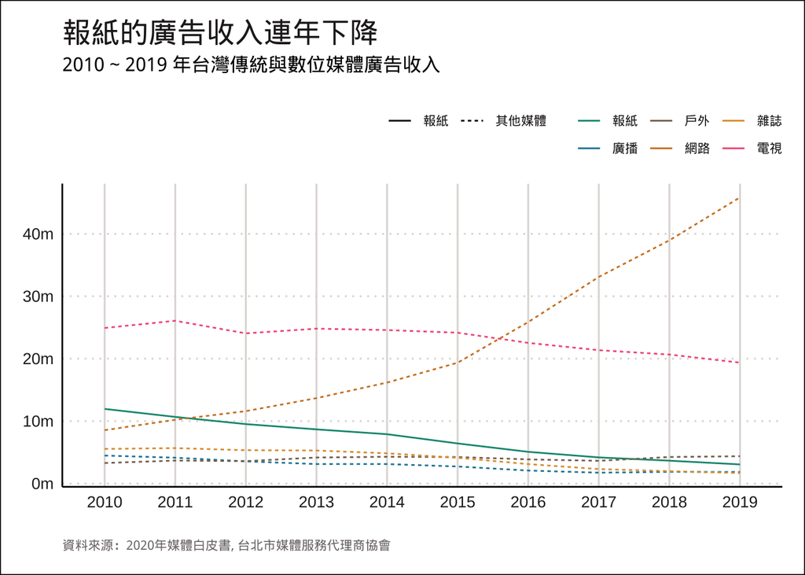

在過去的十年間，網路廣告收入成長超過三倍，相比之下，報紙的廣告收入不到十年前的一半，持續探底不見盡頭。早在十多年前，一篇描寫台灣報業所面臨挑戰的研究（徐榮華，2006）[^3]便提到，報業原先收益頗豐的廣告業務，逐漸被網路廣告侵蝕，人事徵才打不過 104，房地產廣告的效果也比不上動畫或影片說明，其他分類廣告更得和入口網站和搜尋引擎競爭。

除了廣告收入以外，媒體白皮書同時也整理各類媒體的基本資訊，因為受眾的輪廓是廣告效果的基石，底下也選錄白皮書的媒體受眾數據，並繪製成圖表。

將媒體各自受眾按照人口變數切分，先來看不同媒體受眾的性別組成。

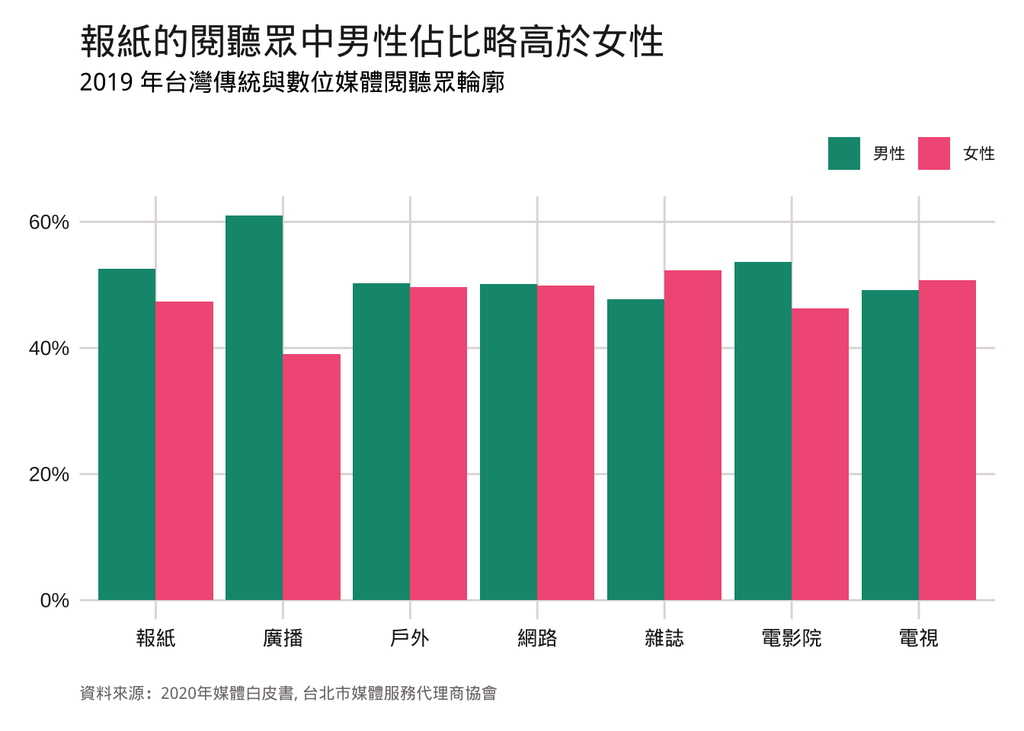

報紙的男性受眾略高於女性受眾，但兩者差距大約僅有百分之五，和電影院的差距相似，雜誌則剛好相反，女性多於男性大約百分之五，電視、網路、戶外都約略相等，差距最大的是廣播的男大於女。

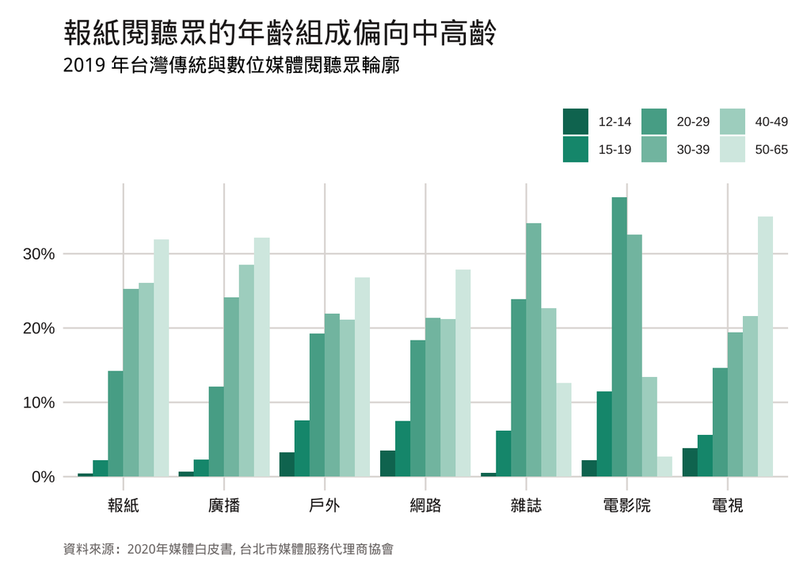

由圖表可以看到，報紙的年齡組成偏向中高齡，分佈呈現負偏(negative skew)，並且相較於其他媒體，報紙缺少 20 歲以下的閱讀年齡層，廣播和雜誌也有類似情況。相較於報紙，儘管電視也是以中高齡閱聽眾人口居多，但仍舊有一定數量的年輕收視族群，網路也是如此。

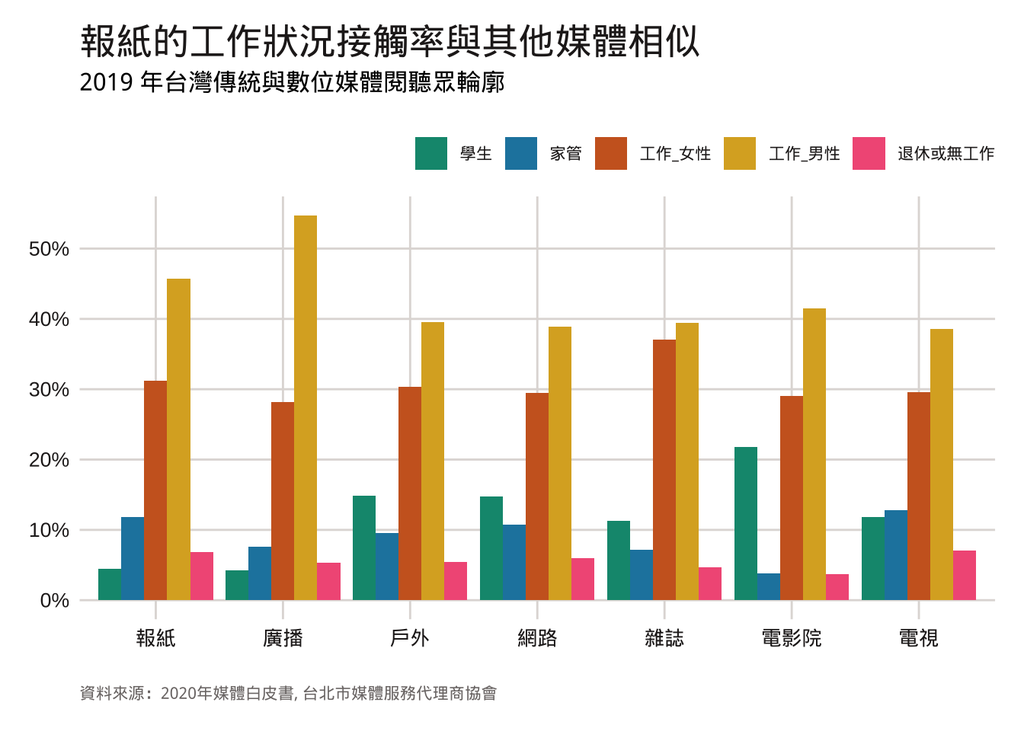

就工作狀況而言，因為調查方法的局限，僅能有較粗的學生、家管、工作中、退休或無工作等族群劃分，各媒體都以工作中的男性最多，工作中的女性次之。和前一項年齡分佈的發現相似，收看報紙和收聽廣播的學生族群佔比最低，不若網路、電影院等媒介，學生族群都能排上第三。

白皮書中也整理了各家報紙的廣告價格、閱讀率等資訊，裡面幾乎涵蓋了台灣所有的報紙[^4]。

[figure not shown]

雖然資料點不多，但報紙的廣告價格和閱讀率呈現明顯的正向線性關係，幾乎可以在圖上直接畫出一條精美的斜直線。

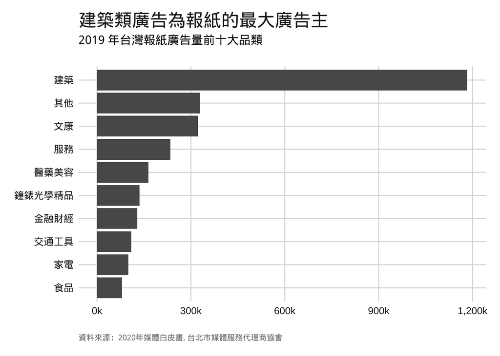

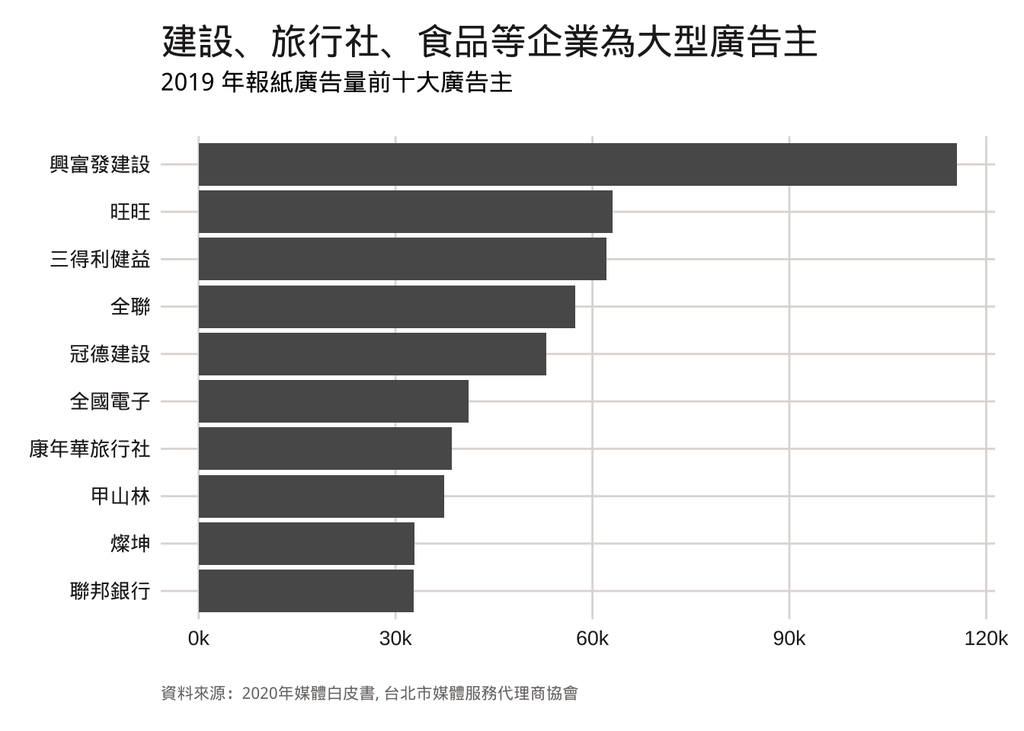

就廣告主的行業而言，以建築類居於第一，廣告量前十大廣告主也有三家屬於建築類。努力回想近期的讀報經驗，稀薄的印象中所見的廣告，的確也都是新建案。

回顧報紙的售報收入與廣告收入，前者呈現直線向下，後者甚至有些曲線向下的趨勢，都沒有好消息。收入的情況不好，支出的情況樂觀得起來嗎？

### 支出

將報業的支出依照生產流程劃分為新聞產製、報紙印刷、配送分發，這部分沒有太多可得的資料，只能提出幾個假設，並以實證研究或者訪談嘗試佐證自己的論述。

首先，以機會成本的概念理解新聞產製，推論請聘僱記者不符效益。媒體前輩和老師都提過記者起薪略高於小編/網路編輯，但相較於能夠以低成本產製新聞的網路媒體，每多聘請一位專職記者或攝影，就犧牲了以更低價格但能產製更多數量、甚至可能更多流量的網路編輯。

媒體經營者若維持既有編制，產製新聞成本相對上升，但如果為了節省成本砍人，或者報導更多網搜中心類型的新聞，例如「引用」爆料公社討論版或者臉書粉絲團的文章，也有可能落入品質降低、訂戶減少的負向迴圈。

產製新聞的下一步是印刷。因為沒有相關數據，無法確定印刷成本是否會因為銷量下降而提昇，但先前有在書中看過，除非報紙的印量低於某個門檻，才會有明顯成本差異。一篇探討報業是否能改用電子紙（陳有全，2004）的研究也提到[^5]，報紙的紙張成本以「每大張」計費，以一份十元的報紙為例，紙張成本佔了約莫五元，又因為四大報目前仍有一定發行量，應不至低於門檻，因此在這先假設印刷成本持平。

稿件交出、報紙編輯排版完成、印刷廠工作到深夜，最後把報紙送到發報作業廠，即將透過派報車，將報紙送到訂貨或零售店家架上。然而，雖然售報能帶來收入，但賣出的報紙份數變多，未必能對毛利帶來正向影響，關鍵還是在於廣告與分銷成本。

在便利商店中，消費者大多以十元購買一份報紙，但報社實際上是以大約五成到六成的價格賣給經銷或零售商，收入僅能與紙張成本的支出打平。徐榮華的研究提到，除了前面討論的紙張成本與印刷費，發行通路費用也是重中之重，每賣出一份報紙，報社就會賠上五塊五，這個數字甚至還沒納入人事成本、電費、折舊等。

在這樣的背景下，報社賣出的報紙量越多，支出反而越高。又因為廣告版面有限，廣告數量無法隨銷售量等比例提升，若無法爭取到早已琵琶別抱的廣告商，售報增量的支出便會蓋過廣告收益。

再回到發行通路，究竟分銷成本有多高？無論是陳有全或徐榮華，給出的大約數字是售報價格的三成，若再加上其他通路費用，像是贈品、運輸費、套報津貼，分銷單位總共拿走售價的四成到五成之間，其中套報津貼是報社給予分銷單位的分潤。

但是，分銷單位也未必好過，它們與報社的關係緊密，卻未必對等，一份研究報告提到[^6]，報社會嘗試轉嫁風險（收不到報費）與成本（賣剩的報紙）給分銷單位。

老師也在課堂上舉例，若訂戶直接找上報社想訂報，報社未必能夠滿足訂戶的訂報需求，因為派人送報紙到特定地區，不符合成本效益。隨著訂戶人數日減，在無法達到規模經濟的情況下，派報的成本只會越來越高，因此我推斷分發成本正在逐漸上升。

### 報紙的收支結構：小結

在此稍作總結

• 收入 = 價格 x 銷量 + 廣告，價格沒有變動，但銷量下降，廣告收入也下降  
• 支出 = 產製 + 印刷 + 分發，產製維持現有會上升、砍人會持平，印刷成本假設持平，分發成本上升

由此可見，報業的狀況實在不佳，不知何時會開始一波新的停刊浪潮。但也有可能出現的不同意見是，即使整體市場變小，但無論餅的規模縮減到何種程度，只要還能掙得一份，不賠錢就好。對於這個論點，我也沒有很好的答案。最近期的例子是 2020 年 6 月初停刊的聯合晚報，停刊說明提到：「受到讀者閱讀習慣改變、數位媒體發展和新冠肺炎疫情等因素影響，聯晚決定終止發行。」老師和我們說，規模並不是存續的依歸，因為發行量比不上四大報的經濟日報也能獲利，沒道理其他報紙就必然會被掃進歷史的牆角。

## 如何應變

依照上面的邏輯，我嘗試分別從收入與支出的角度，看是否有可以調整之處。若不改變現有的等式，則報紙能做的是提高售價、增加或至少維持訂戶、增加廣告收益，若想改變現有等式，那應該增加收入來源，也就是前幾部分一直沒討論到的副業收入。

### 維持現有：提高售價

提高報紙售價可行嗎？一篇爬梳台灣報業發展的研究中提到（林麗雲，2008）[^7]，1996 年時，聯合與中時因應國際紙價上漲，將報紙售價調高成 15 元，但自由時報維持 10 元的售價，「這波價格戰後，兩大報的發行量，掉了一成三到二成之間。」兩大報只好靠贈品、贈報、抽獎等方式因應，但對價格敏感的讀者來說，待優惠活動結束後，仍會回到價格低者的懷抱。

另外，在一篇討論報紙價格彈性的研究中[^8]，結論提到了兩個值得注意的重點，第一，報紙需求的彈性係數較低，影響報紙需求量的主要因素是報紙的品質；第二，專業報紙的價格彈性係數較綜合報紙的價格彈性係數低。台灣四大報都屬於綜合報，若貿然調漲價格，很容易便會嚇跑讀者。若要漲價，報紙必須選擇走向差異化。

### 維持現有：增加/維持訂戶

關於這點，此處沒有要深入論述，如同前述所提，面向大眾的報紙已不再具備壟斷資訊的能力，在整體市場規模下降、閱報人數越發稀少的情況下，增加訂戶有難度，能做到止損便已經很好，除非改變報紙走向，否則很難維持訂戶。

### 維持現有：增加廣告收入

這點和前述類似，廣告收入和閱讀率同步下跌，連止損都有困難。和組員討論的時候，我們有另外想到線上與線下的合作，譬如將數位內容搬到實體、將實體內容搬到線上，在變換媒介的過程中，看是否能夠調整報導呈現手法，這大概是絞盡腦汁也想不到新點子的天真想法吧。

然而，這樣的想法也有危險。有好幾篇在網路媒體逐漸抬頭的時期討論線上新聞是否會競蝕線下新聞的研究 [^9] [^10] [^11]，也就是自家網路新聞與報紙爭搶用戶的情況。2000 年初期的文章說，競蝕確實有機會發生，但影響不大，而 2015 年的文章則說，競蝕的現象是 “credible consideration”。

### 增加收入來源：多角化

如同老師在課堂上所分享，聯合報系目前也採取多元的方式增加收入來源，譬如進攻文創、提供資訊服務等方式。然而，不管究竟採取何種方式，我們還是必須回答，艱困的報紙主業該如何生存的問題。

### 如何應變：小結

稍微整理上面所說

**維持現有**  
• 增加/維持訂戶 - 平面媒體市場寒冬難以倖免  
• 提高報紙售價 - 價格彈性因品質而異，大眾媒體價格彈性高  
• 提升廣告收入例如與數位部門合作 - 可能發生競蝕

## 新的方向與結語

說了那麼多，報紙究竟該如何，討論到最後，大家都很悲觀。報紙的資訊不具有獨佔性、內容也非客製化、受眾仍舊設定為大眾，看起來是不太可能停止衰退了，也有人提出乾脆收掉的建議。當然，我們也可以向成功存活的報紙取經，目前看起來有兩條路可以選。

### 兩種路線

第一種是面向國際市場的紐約時報、華爾街日報路線， IEO 國際經濟觀察在 [〈 反川這門生意：廣告下滑，訂閱上升、投資Podcast。紐時能為媒體未來指路？〉](https://vocus.cc/article/5ff964fcfd89780001b1a78c) 一文中提到，「若看完紐時和華爾街日報，可能會覺得訂閱制媒體大有可為前途大好。不過要注意的是這是這是基於紐約時報和華爾街日報，兩者都是具有全球知名度的權威媒體品牌，並且使用主流語言英文，也因此能有非常廣闊的可開發市場空間，也更有底氣以訂閱收入取代廣告，並維持非常大的編輯室編制。…大者恆大，頭部的廠商能夠獲取最大部分的用戶和利潤。」台灣的自由時報或者聯合報有辦法走這樣的模式嗎？首先想到的是市場問題，儘管國際上使用中文者眾多，但有很大多數中文人口集中於對岸，不像英文作為全球通用語言的地位，再來，當然也有政治問題，對岸有許多傾國家之力補助支援的媒體，自由和聯合都缺乏相關資源。

第二種則是轉型地方化、小眾化的路線，譬如美國就有鎖定新興郊區居民的地方性報紙，《關鍵轉折：內容媒體的科技轉型之路》書中便曾討論相關案例。不過，因為疫情緣故，華爾街日報曾[報導](https://www.storm.mg/article/2603328?mode=whole)，有許多間地方性的報社面臨沈重打擊，多位新聞機構的員工遇到無薪假或者被開除。

台灣現在也有地方性的報社，但以它們的營運模式來說，並不適合作為四大報轉型誒地方或小眾化報紙的模板。另外，就人口結構與住商分佈而言，似乎也不若美國有以特定區域為基地發展地方化報紙的本錢。

**兩種路線**  
• 有大市場、大量訂戶養人 e.g. 面向國際的紐時、WSJ  
• 轉型地方化、小眾化，但因疫情地方報社受到打擊

### 差異化

當然，不一定非要以地域區分，報社也可以走差異化路線。事實上，課堂上的各組報告，幾乎也都從這個角度出發。舉例來說，我的小組成員們便提及報紙週刊化、深度報導化、讀者客製化等。下方簡單列點說明：

**差異化**  
• 減少發行頻率，成效是減少日常發行的新聞產製和印刷成本，將成本轉移到產製長篇新聞，潛在問題則是發行頻率低，造成總銷售量下降，利潤降低，而報社運營成本不變，因此轉型初期需要基金投資。  
• 發展深度報導 差異化策略:與網路新聞的短、即時和軟性居多相區隔，報紙 將著重在深度調查報導。  
• 專門發展讀者偏好內容：對現有讀者進行意見調查，瞭解讀者偏好，將受歡迎版面擴大，為現有讀者客製化報紙新聞內容。

也有其他鎖定利基市場的選項，譬如專攻文藝(譬如 verse)、專攻教育等路線，又或者是改走菁英路線(聽起來像商周)等想法，因為這些大膽的點子並沒有數據佐證，很容易變成各說各話，因此，本文也將在邁入結尾。

### 結語

報業失去壟斷資訊的地位後，不再能以大眾媒體生存。無論是從收入的售報或者賣廣告，還是從支出面的產製、印刷、派發，報業面臨市場萎縮的困境，提高售價有價格彈性高的困難，維持訂戶又不容易，還有可能遇到競蝕現象，縱然能發展副業，仍要解決報紙主頁去留問題。未來可以走的路線不多，要不像紐時依樣，要不走向地區化、小眾化，或者差異化。但要鎖定哪些人？走深度報導路線真能維繫命脈嗎？對於這些問題，答案仍在未定之天，只有真正碰到數字，才敢做出結論，要不就都只是難以證偽且沒太大價值的假想而已。

寫這篇文一方面是留下紀錄，一方面是難得有機會取得過去十多年的報紙發行量數字，還有報紙受眾的基本資訊，想畫成圖表，用更好的方式闡述問題。因為對報紙產業不夠理解，過程中找了其他資料，有些論文的作者是學者出身，也有幾篇是媒體從業人員拿自己的工作當成研究題目，這才有機會一窺報業的歷史。若所寫的內容有錯，還請不吝指正。

最後謝謝聯合報系的張立老師，以及所上麗雲老師的豐富研究，讀老師寫的論文就像在讀故事書一樣，很有畫面感。當然也謝謝組員 Vivian, Wendy, Tina, Lian ，還有 Steven, Helene, Ting-Ni, Kerwin 提供意見。

[^1]: 商業週刊、爽報、壹週刊、蘋果日報、自由時報、智富月刊、米娜時尚等紙媒都曾委託 ABC 稽核發行量。據 ABC 的稽核報告顯示，自由時報 2007 年到 2017 年之間都曾經請 ABC 稽核，橫跨超過十年，蘋果日報則僅有 2006 年到 2008 年的稽核報告。
[^2]: 市場整體的近七天報紙閱讀率為 21.55%，最高者為自由時報的 9.45%，聯合報的 8.13%次之。
[^3]: 徐榮華. (2006). 台灣報業經營困境與因應策略.政治大學傳播學院碩士在職專班學位論文, 1-264.
[^4]: 原始資料中更生日報、國語日報、台灣時報、人間福報的廣告價格為空值，台灣新生報的閱讀率為空值，都不計入；經濟日報的周間廣告價格為二十萬元、假日廣告價格為十萬元，取其平均十五萬元。另外，資料也包含聯合晚報，因聯合晚報現已停刊，也不計入。
[^5]: 陳有全（2004）。未來報紙的發展－台灣報業應用電子紙之研究。國立中山大學高階經營碩士班碩士論文，高雄市。 取自https://hdl.handle.net/11296/2q9q64
[^6]: 台大〈工作社會學〉 2005 年修課學生的田野觀察，http://homepage.ntu.edu.tw/~pclan/documents/report_samples/05_sociology_work/paperdiver.pdf
[^7]: 林麗雲. (2008). 變遷與挑戰: 解禁後的台灣報業. *新聞學研究*, (95), 183-212.
[^8]: 向志强, & 陈鸥鸥. (2006). 报纸需求弹性与报纸定价研究. 當代傳播, 2006(3), 40-43.
[^9]: Sridhar, S., & Sriram, S. (2015). Is online newspaper advertising cannibalizing print advertising?. Quantitative Marketing and Economics, 13(4), 283-318.
[^10]: 蔡卓芳, 鍾珮琦, & 齊湘. (2003). 台灣新聞網站市場範圍與市場競爭初探—以《聯合新聞網》,《中時電子報》,《東森新聞報》 三大新聞網站為例分析 (Doctoral dissertation).
[^11]: Deleersnyder, B., Geyskens, I., Gielens, K., & Dekimpe, M. G. (2002). How cannibalistic is the Internet channel? A study of the newspaper industry in the United Kingdom and the Netherlands. International Journal of Research in Marketing, 19(4), 337-348.